# Executive Summary

Hugo César Octavio del Sueldo

11/23/2020

## Introducción

Colgate dominaba en 1956 el mercado de venta de crema dental en EEUU en posesión de un 50% de la cuota de mercado. En dicho año, Crest (Procter and Gamble) introduce en el mercado estadounidense su propia pasta de dientes y se posiciona como un competidor débil contra Colgate ocupando en el paso de los dos años siguientes un máximo de un 15% de cuota de mercado. Sin embargo, en el 1 de agosto de 1960 el Consejo de Terapéutica Dental de la American Dental Association (ADA) aprobó a Crest como una “ayuda importante en cualquier programa de higiene dental”. Este hecho combinado con una importante campaña de marketing por parte de Procter and Gamble, cambia de manera radical el posicionamiento de Crest respecto a Colgate sobrepasándole a las pocas semanas en cuota de mercado y consolidándose como líder del mercado estadounidense a partir de Diciembre de 1961. En este informe se razona como esta campaña de marketing ha tenido unos efectos muy significativos y duraderos que se han preservado en el tiempo. Se trabaja con datos desde enero de 1958 a abril de 1963, un periodo de tiempo suficientemente amplio para observar tanto las tendencias previas a la intervención de ADA como sus consecuencias.

Para dicho estudio se cuenta con una base de datos que muestra las cuotas de mercado registradas semanalmente por Colgate y Crest respectivamente desde el 8 de enero de 1958 hasta el 17 de abril de 1963. La base de datos se encuentra sin valores nulos ni registros erróneos. Una visualización inicial de los datos muestra a simple vista la importancia de este caso de estudio. Se puede localizar de un golpe de vista el punto en el que Crest comienza su escalada una semana después de las declaraciones de ADA y como una parte de su crecimiento se debe precisamente al detrimento de Colgate:

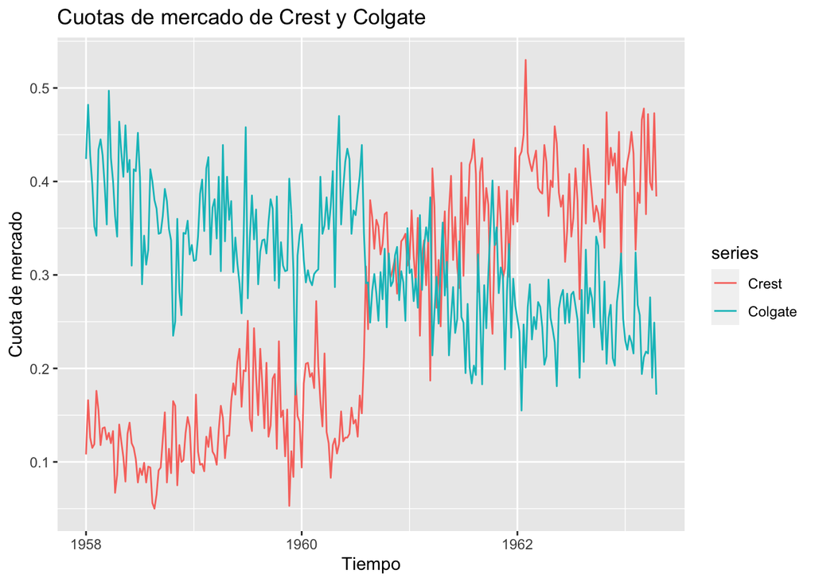

```r
#Plot con las dos series en el mismo grafico
autoplot(mydata, facets = FALSE) +
  ggtitle("Cuotas de mercado de Crest y Colgate") +
  xlab("Tiempo") +
  ylab("Cuota de mercado")
```

Colgate experimentó una fuerte bajada a mediados del año 1960 y fue fruto de que el 1 de agosto de 1960, el Consejo de Terapéutica Dental de la American Dental Association (ADA) aprobó a Crest como una “ayuda importante en cualquier programa de higiene dental” y por tanto afectó significativamente a sus ventas. No obstante esto, se puede observar que la tendencia en las ventas de Colgate era decreciente y aparentemente parece no tener un comportamiento estacional. Comienza con un market share de 0.425 y luego cae fuerte a 0.172 en el final de la serie.

## Modelos ARIMA

### ARIMA para Crest

En el modelo ARIMA, desde el punto de vista estocástico o moderno, tenemos tres parámetros de los que nos tenemos que preocupar, los cuales forman un modelo ARIMA no estacionario y se clasifica como un modelo “ARIMA (p, d, q) x (P,D,Q)” pero solo dispondremos de la parte regular porque nuestro modelo no tiene componente estacional, donde:

- p es el número de términos autorregresivos,
- d es el número de diferencias necesarias para la estacionariedad, y
- q es el número de retardos que contiene el modelo de medias móviles.

### ARIMA para Colgate

Este test lo que nos indica es como se distribuyen los residuos de los datos, es un contraste de hipótesis en el que la hipótesis nula indica que los residuos de los datos se distribuyen de manera independiente, por tanto, decimos que no existe autocorrelación entre los residuos y por tanto existe ruido blanco. Por tanto, buscamos un valor alto para nuestro P-valor con objetivo de aceptar la hipótesis nula, y eso nos indica que los residuos no tiene autocorrelación, gracias a esto podemos continuar con el análisis.

## Forecast de los modelos ARIMA para Crest y Colgate

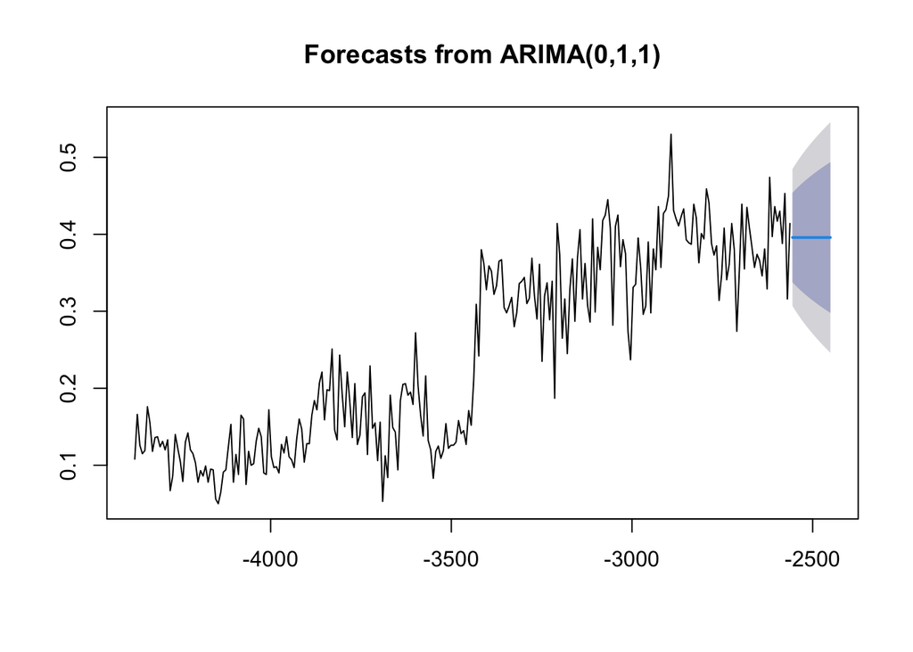

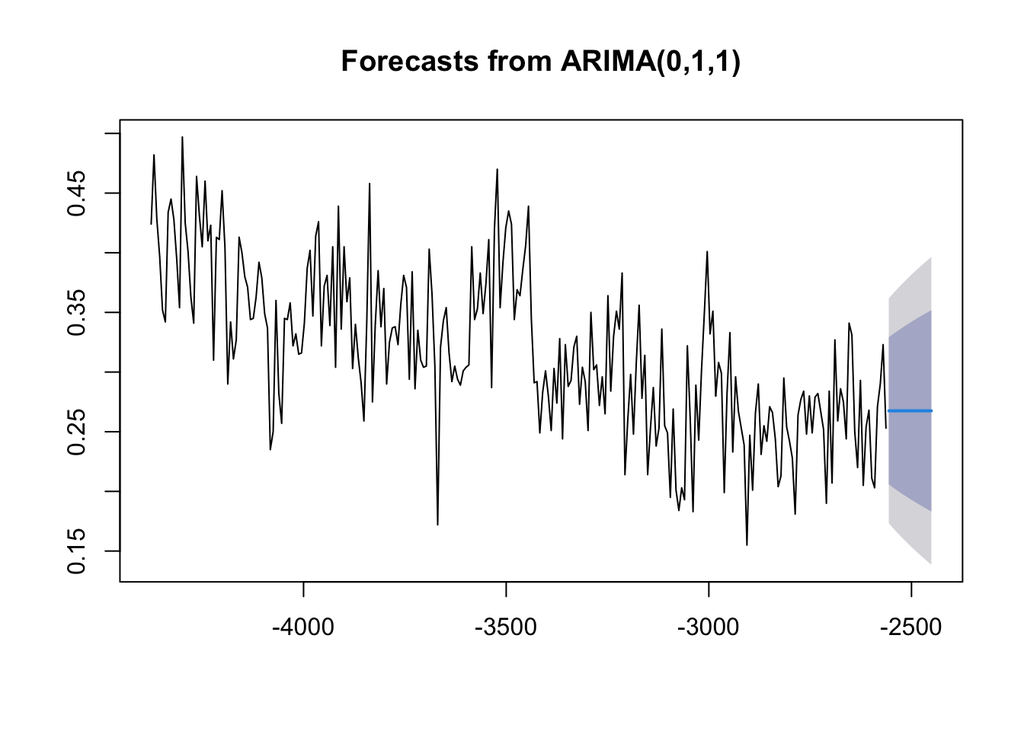

El forecast que vemos nos indica la predicción y podemos observar que tiene una predicción correcta ya que sigue la tendencia. La prediccion aparenta ser una linea recta pero se debe a la aplicacion de un solo retardo sobre nuestro modelo. La línea azul indica la media de la predicción, la región más oscura es donde se localizarán con un 80% de probabilidad las cuotas durante este periodo. La región contenedora aun más clara eleva la probabilidad de pertenencia hasta el 95%.

### Busqueda y eliminacion de Outliers

Ahora vamos a proceder analizar los outliers tanto aditivos (afectan a la serie temporal) e innovativos (afectan al error) entonces vamos a analizar, los outliers para ambas empresas.

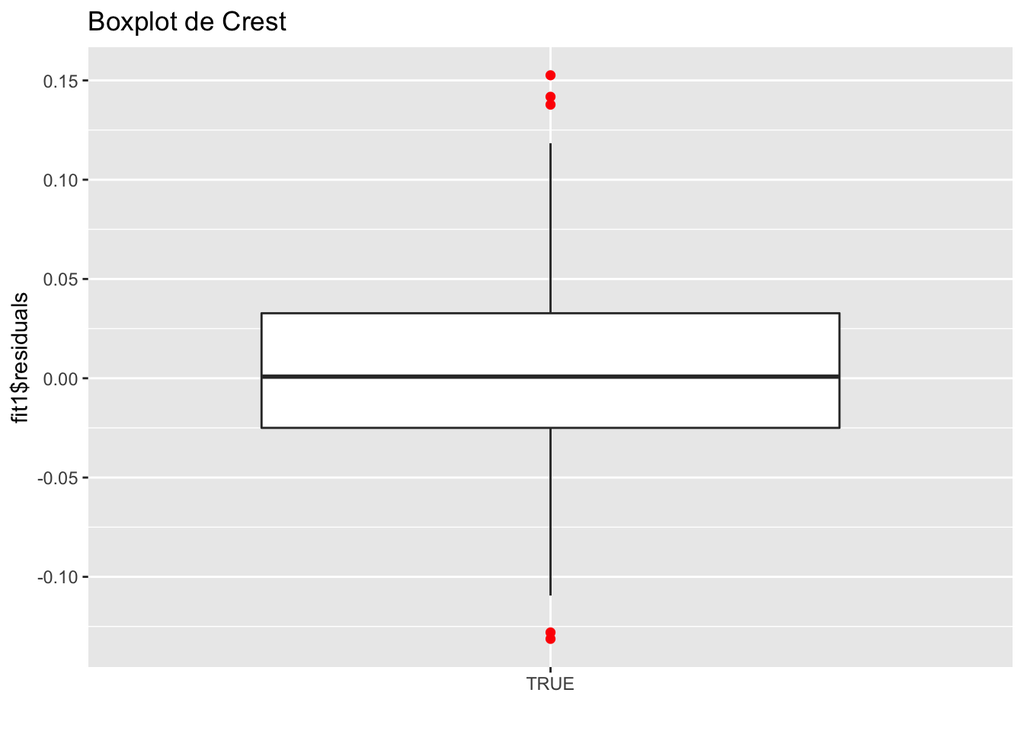

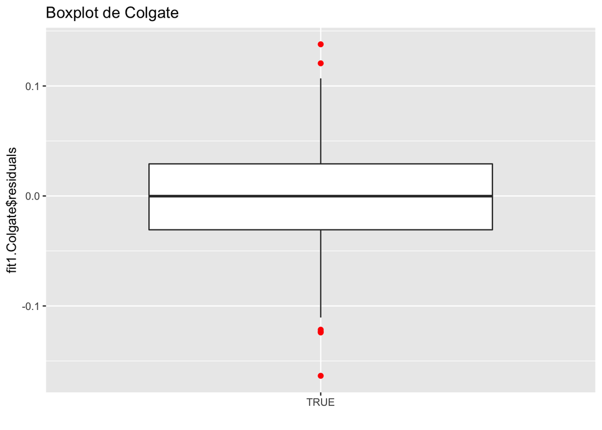

Con el Boxplot podemos observar la presencia de outliers en los datos de Crest como de Colgate. Teniendo en cuenta esto, utilizamos la funcion tso para poder encontrar estos outliers exactamente y para ver como afectan los mismos a las series temporales

```
## Series: colgate_training
## Regression with ARIMA(0,1,1)(1,0,0)[52] errors
##
## Coefficients:
##           ma1     sar1     TC43    AO102    LS136   TC196
##       -0.8621  -0.0036  -0.1303  -0.1607  -0.0996  0.1417
## s.e.   0.0333   0.0698   0.0346   0.0418   0.0223  0.0344
##
## sigma^2 estimated as 0.001918:  log likelihood=445.04
## AIC=-876.09   AICc=-875.64   BIC=-851.19
##
## Outliers:
##   type ind    time  coefhat  tstat
## 1   TC  43 1958:43 -0.13034 -3.769
## 2   AO 102 1959:50 -0.16068 -3.841
## 3   LS 136 1960:32 -0.09958 -4.475
## 4   TC 196 1961:40  0.14171  4.114
```

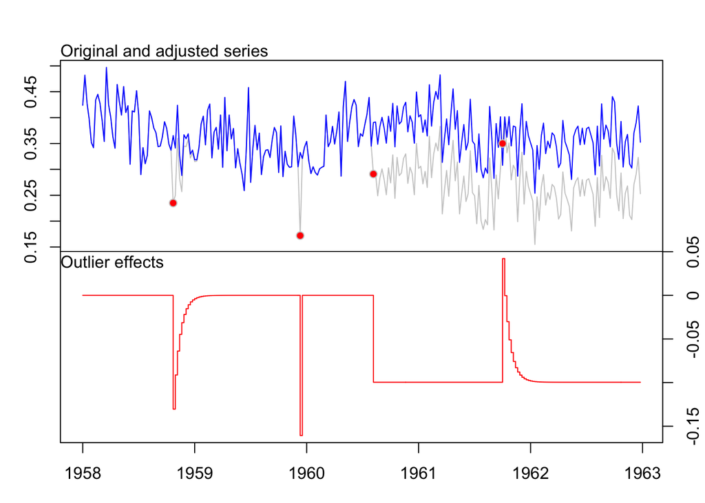

```
##          Length Class          Mode
## outliers   5    data.frame     list
## y        260    ts             numeric
## yadj     260    ts             numeric
## cval       1    -none-         numeric
## fit       19    forecast_ARIMA list
## effects  260    ts             numeric
## times      4    -none-         numeric
```

En ambas figuras se se presentan en azul las series ajustadas y en un gris más desvaído la serie real totalmente alterada por el efecto de las observaciones atípicas.

Aca observamos, para Colgate, que tiene outliers en las semanas 43, 102, 136 y 196. Al mismo tiempo observamos el comportamiento de estos outliers en la serie. Podemos observar que los dos primeros son impulsos y el tercero es un escalon ya que a partir de aqui cambia el comportamiento de la serie. Este escalon se da en la semana 136 cuando la ADA anuncia que va a ayudar a Crest

```
## Series: crest_training
## Regression with ARIMA(0,1,1) errors
##
## Coefficients:
##           ma1   LS136    AO167    TC196
##       -0.7725  0.1619  -0.1432  -0.1312
## s.e.   0.0477  0.0270   0.0387   0.0342
##
## sigma^2 estimated as 0.001712:  log likelihood=458.97
## AIC=-907.95   AICc=-907.71   BIC=-890.16
##
## Outliers:
##   type ind    time coefhat  tstat
## 1   LS 136 1960:32  0.1619  5.990
## 2   AO 167 1961:11 -0.1432 -3.701
## 3   TC 196 1961:40 -0.1312 -3.831
```

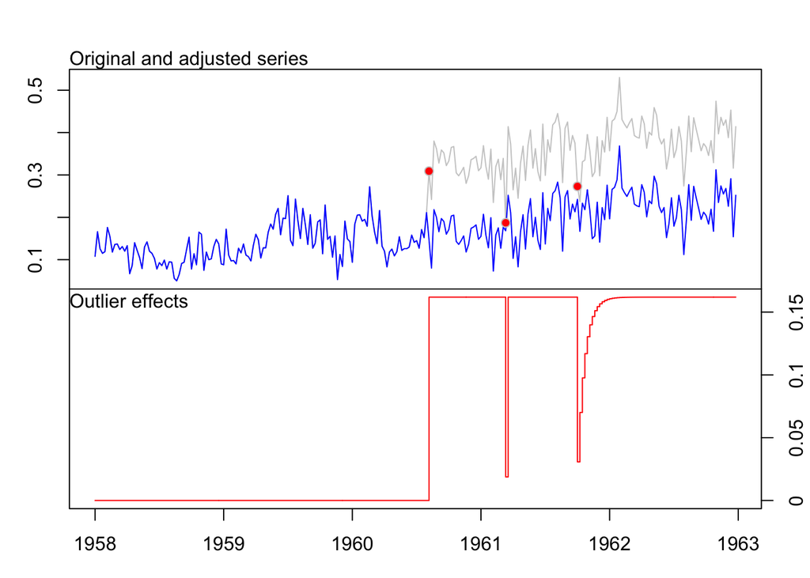

```
##          Length Class          Mode
## outliers   5    data.frame     list
## y        260    ts             numeric
## yadj     260    ts             numeric
## cval       1    -none-         numeric
## fit       19    forecast_ARIMA list
## effects  260    ts             numeric
## times      3    -none-         numeric
```

Aca podemos observar claramente los outliers de Crest en la semana 136 (coincide con Colgate), 167 y 196. Al mismo tiempo se puede visualizar muy bien la indidencia de los mismos

## Funcion de transferencia

```r
mod.transf.colgate <- arimax(x = colgate_training,
                             order = c(0, 1 ,1),
                             xtransf = data.frame(crest_training), #atipico aditivo
                             transfer = list(c(0,0)), #primero el step y luego el pulse
                             method = "ML")
mod.transf.colgate
```

```
##
## Call:
## arimax(x = colgate_training, order = c(0, 1, 1), method = "ML", xtransf = data.frame(crest_training),
##     transfer = list(c(0, 0)))
##
## Coefficients:
##           ma1  crest_training-MA0
##       -0.8345             -0.4946
## s.e.   0.0362              0.0551
##
## sigma^2 estimated as 0.001776:  log likelihood = 452.04,  aic = -900.08
```

## **Conclusiones**

En este informe hemos podido analizar la evolucion de las cuotas de mercado de dos marcas competidoras. El mercado estaba liderado por la crema dental Colgate, pero esta se vio afectada por la intenvención de la ADA al aprobar la crema dental Crest.

Para poder llevar a acabo la prediccion de las 16 semanas de 1963 hemos utilizado un modelo ARIMA (0,1,1) que mejoramos tratando los puntos atípicos y que nos indica que las cuotas de mercado de las dos compañias se mantendrán estables en el tiempo.